# MPG: Does Transmission Type Matters?

## Executive Summary

In this document we analyse the transmission type effect in the MPG performance for a vehicle. We fitted a linear model and studied how the car characteristics like engine size, cylinder displacement and others can influence. Hopefully this study will help people make better choices in their next car selection regarding this important economical and environmental issue.

## Exploratory Analisys

First, we want to understand how the factors relates to the outcome and how they relates to each other. Some of the variables are highly correlated, meaning that they measure almost the same thing. That is the case for **displacement** vs **cyl**, so we probably can use only one of those.

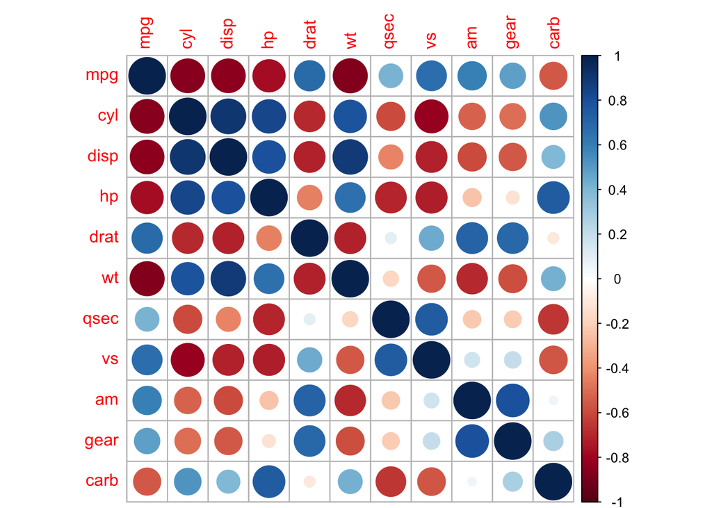

## Model

To select the final model we used a **backward-elimination** strategy which consists of:

```r
# Fitting the model using all variables and finding best predictors
modelFull  <- lm(mpg ~ ., data=mtcars)
final <- step(modelFull, direction = "backward", trace=F)
```

In **modelFull** we fitted the model with all predictors. Then, using the **step()** function we select and fit the best model. The **final** variable holds this model. We can look the expression for our final model by looking at *final$call$formula*: mpg ~ wt + qsec + am.

It means that the predictors that we will use are **wt**, **qsec** and **am**. We will look at the coefficient and the interpretation for each predictor.

```
## (Intercept)          wt        qsec          am
##    9.617781   -3.916504    1.225886    2.935837
```

## Residual plot/diagnostics

To check that our model is a good representation of the phenomena under study we plotted the residuals and the QQ Plot. As we can see, the model is a good fit and can be used for further investigation on variables that affects fuel consumption.

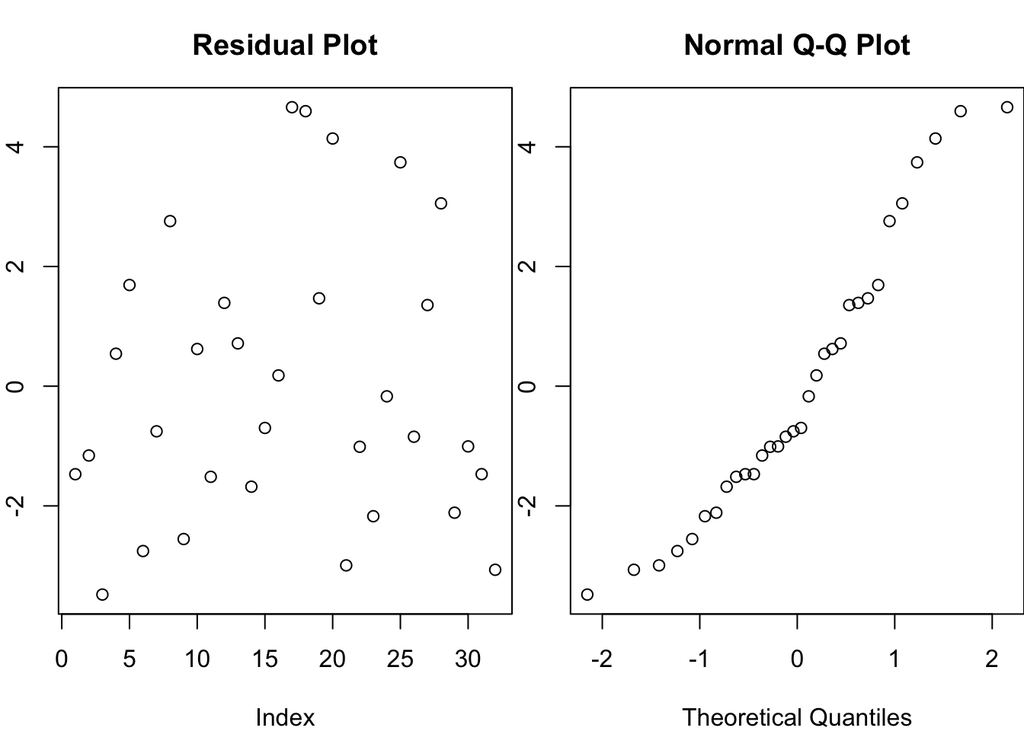

We can also create 95% confidence intervals for our coefficients. We can use this information to check if we have enough evidence to conclude that one of the two transmission types are better in MPG performance.

```
##              Estimate Std..Error         min       max
## (Intercept)  9.617781  6.9595930 -4.63829946 23.873860
## wt          -3.916504  0.7112016 -5.37333423 -2.459673
## qsec         1.225886  0.2886696  0.63457320  1.817199
## am           2.935837  1.4109045  0.04573031  5.825944
```

Our confidence interval for the **am** variable does not include 0, so we have evidence that changing the transmission type really affects car MPG.

## Conclusions

From our modeling we were able to conclude that manual transmissions is better for MPG. The difference is 2.94 MPG (+/- 2.89) improved mileage.